# Problem Set 3, due Wednesday, May 3rd, 5:30pm.

## Introduction to the assignment

For this assignment, you will be using data from the [Progresa program](http://en.wikipedia.org/wiki/Oportunidades), a government social assistance program in Mexico. This program, as well as the details of its impact, are described in the paper "[School subsidies for the poor: evaluating the Mexican Progresa poverty program](http://www.sciencedirect.com/science/article/pii/S0304387803001858)", by Paul Shultz (available on Canvas). The data (progresa_sample.csv.gz) is available on canvas in files/data.

Please read the paper to familiarize yourself with the PROGRESA program before beginning this problem set, so you have a rough sense of where the data come from and how they were generated. If you just proceed into the problem set without understanding Progresa or the data, it will be very difficult!

The goal of this problem set is to implement some of the basic econometric techniques that you are learning in class to measure the impact of Progresa on secondary school enrollment rates, in particular differences-in-differences. Your task is to **estimate the impact of *progresa* subsidies on the school attendance**. Note: this asks to estimate a causal effect.

The timeline of the program was:

- Baseline survey conducted in 1997
- Intervention begins in 1998, "Wave 1" of data collected in 1998
- "Wave 2 of data" collected in 1999
- Evaluation ends in 2000, at which point the control villages were treated.

When you are ready, download the progresa_sample.csv data from Canvas. The data are actual data collected to evaluate the impact of the Progresa program. In this file, each row corresponds to an observation taken for a given child for a given year. There are two years of data (1997 and 1998), and just under 40,000 children who are surveyed in both years. For each child-year observation, the following variables are collected:

| Variable name | Description |
| --- | --- |
| year | year in which data is collected |
| sex | male = 1 |
| indig | indigenous = 1 |
| dist_sec | nearest distance to a secondary school |
| sc | enrolled in school in year of survey (=1) |
| grc | grade enrolled |
| fam_n | family size |
| min_dist | min distance to an urban center |
| dist_cap | min distance to the capital |
| poor | poor = "pobre", not poor = "no pobre" |
| progresa | treatment = "basal", control = "0" |
| hohedu | years of schooling of head of household |
| hohwag | monthly wages of head of household |
| welfare_index | welfare index used to classify poor |
| hohsex | gender of head of household (male=1) |
| hohage | age of head of household |
| age | years old |
| folnum | individual id |
| village | village id |
| sc97 | enrolled in school in 1997 (=1) |

## Part 1: Descriptive analysis

### 1.1 Summary Statistics

Report summary statistics (mean, standard deviation, and number of missings) for all of the demographic variables in the dataset (i.e., everything except year, folnum, village). Present the actual levels for 'progresa' and 'poor'. Do these fit with the documentation above?

Present these in a single table alphabetized by variable name. Do NOT simply expect the grader to scroll through your output!

```python
#IPython is what you are using now to run the notebook
import IPython
print( "IPython version:      %6.6s (need at least 1.0)" % IPython.__version__)

# Numpy is a library for working with Arrays
import numpy as np
print( "Numpy version:        %6.6s (need at least 1.7.1)" % np.__version__)

# SciPy implements many different numerical algorithms
from scipy.stats import ttest_ind

# Pandas makes working with data tables easier
import pandas as pd
print( "Pandas version:       %6.6s (need at least 0.11.0)" % pd.__version__)

# Module for plotting
import matplotlib.pyplot as plt
%matplotlib inline
# necessary for in-line graphics

# SciKit Learn implements several Machine Learning algorithms
import sklearn
print( "Scikit-Learn version: %6.6s (need at least 0.13.1)" % sklearn.__version__)
import statsmodels.formula.api as smf
```

```
IPython version:       6.1.0 (need at least 1.0)
Numpy version:        1.13.3 (need at least 1.7.1)
Pandas version:       0.20.3 (need at least 0.11.0)
Scikit-Learn version: 0.19.1 (need at least 0.13.1)
```

```python
progresa_df = pd.read_csv('progresa_sample.csv.gz')
progresa_df.head()
```

|  | year | sex | indig | dist_sec | sc | grc | fam_n | min_dist | dist_cap | poor | ... | hohedu | hohwag | welfare_index | hohsex | hohage | age | village | folnum | grc97 | sc97 |
| --- | --- | --- | --- | --- | --- | --- | --- | --- | --- | --- | --- | --- | --- | --- | --- | --- | --- | --- | --- | --- | --- |
| 0 | 97 | 0.0 | 0.0 | 4.473 | 1.0 | 7.0 | 7 | 21.168384 | 21.168384 | pobre | ... | 6 | 0.0 | 583.0 | 1.0 | 35.0 | 13 | 163 | 1 | 7 | 1.0 |
| 1 | 98 | 0.0 | 0.0 | 4.473 | 1.0 | 8.0 | 7 | 21.168384 | 21.168384 | pobre | ... | 6 | 0.0 | 583.0 | 1.0 | 35.0 | 14 | 163 | 1 | 7 | 1.0 |
| 2 | 97 | 1.0 | 0.0 | 4.473 | 1.0 | 6.0 | 7 | 21.168384 | 21.168384 | pobre | ... | 6 | 0.0 | 583.0 | 1.0 | 35.0 | 12 | 163 | 2 | 6 | 1.0 |
| 3 | 98 | 1.0 | 0.0 | 4.473 | 1.0 | 7.0 | 7 | 21.168384 | 21.168384 | pobre | ... | 6 | 0.0 | 583.0 | 1.0 | 35.0 | 13 | 163 | 2 | 6 | 1.0 |
| 4 | 97 | 0.0 | 0.0 | 4.473 | 1.0 | 2.0 | 7 | 21.168384 | 21.168384 | pobre | ... | 6 | 0.0 | 583.0 | 1.0 | 35.0 | 8 | 163 | 3 | 2 | 1.0 |

5 rows × 21 columns

```python
# displaying size and columns of the dataframe
print(progresa_df.shape)
print(progresa_df.columns)
```

```
(77250, 21)
Index(['year', 'sex', 'indig', 'dist_sec', 'sc', 'grc', 'fam_n', 'min_dist',
       'dist_cap', 'poor', 'progresa', 'hohedu', 'hohwag', 'welfare_index',
       'hohsex', 'hohage', 'age', 'village', 'folnum', 'grc97', 'sc97'],
      dtype='object')
```

```python
list_summary = list()
progresa_df_1 = progresa_df.drop(['progresa', 'poor', 'year', 'folnum', 'village'], axis = 1)

columns = list(progresa_df_1.columns)
# looping over the columns and calculating mean, standard deviation and sum number of missing values
for col in columns:
    col_mean = progresa_df_1[col].mean()
    col_std = progresa_df_1[col].std()
    col_missing = progresa_df_1[col].isnull().sum()
    list_summary.append({'column name':col,'mean':col_mean, 'std':col_std, 'missing values':col_missing})

summary_stats = pd.DataFrame(list_summary)
print(summary_stats)
print('\nDistribution of progresa\n', pd.value_counts(progresa_df.progresa))
print('\nDistribution of poor\n', pd.value_counts(progresa_df.poor))
```

```
      column name        mean  missing values         std
0             sex    0.512211              24    0.499854
1           indig    0.298324             300    0.457525
2        dist_sec    2.418910               0    2.234109
3              sc    0.819818            8453    0.384342
4             grc    3.963537            6549    2.499063
5           fam_n    7.215715               0    2.352900
6        min_dist  103.447520               0   42.089441
7        dist_cap  147.674452               0   76.063134
8          hohedu    2.768104               0    2.656106
9          hohwag  586.985312               0  788.133664
10  welfare_index  690.346564             210  139.491130
11         hohsex    0.925185              20    0.263095
12         hohage   44.436717              10   11.620372
13            age   11.366460               0    3.167744
14          grc97    3.705372               0    2.572387
15           sc97    0.813922            3872    0.389172

Distribution of progresa
 basal    47560
0        29690
Name: progresa, dtype: int64

Distribution of poor
 pobre       65392
no pobre    11858
Name: poor, dtype: int64
```

### 1.2 Differences at baseline?

Now let's investigate the differences in baseline. Are the baseline (1997) demographic characteristics **for the poor** different in treatment and control villages?

I suggest you to use a T-Test to determine whether there is a statistically significant difference in the average values of each of the variables in the dataset. Focus only on the data from 1997 for poor.

Present your results in a single table with the following columns and 14 (or so) rows:

| Variable name | Average value (Treatment villages) | Average value (Control villages) | Difference (Treat - Control) | p-value |
| --- | --- | --- | --- | --- |
| Male | ? | ? | ? | ? |

```python
progresa_97_df = progresa_df[progresa_df.year==97][progresa_df.poor=='pobre']
print(progresa_97_df.shape)
progresa_97_df.dropna(axis = 0, inplace=True)

diff_at_baseline=[]
for col in columns:
    # creating dataframe for treatment group
    treatment_df = progresa_97_df[progresa_97_df.progresa =='basal']
    # creating dataframe for control group
    control_df = progresa_97_df[progresa_97_df.progresa == '0']
    mean_treatment = treatment_df[col].mean()
    mean_control = control_df[col].mean()
    # performing T-test
    t_test = ttest_ind(treatment_df[col], control_df[col])
    diff_at_baseline.append({'Variable Name':col,'Avg(Treatment villages)':mean_treatment,'Avg(Control Villages)':mean_control, 'Difference':mean_treatment - mean_control, 'p-value':t_test.pvalue})

diff_baseline_df = pd.DataFrame(diff_at_baseline)
# Renaming columns
diff_baseline_df = diff_baseline_df[['Variable Name', 'Avg(Treatment villages)', 'Avg(Control Villages)', 'Difference', 'p-value']]
diff_baseline_df
```

```
(32696, 21)
```

|  | Variable Name | Avg(Treatment villages) | Avg(Control Villages) | Difference | p-value |
| --- | --- | --- | --- | --- | --- |
| 0 | sex | 0.520268 | 0.506556 | 0.013713 | 1.956962e-02 |
| 1 | indig | 0.316744 | 0.325306 | -0.008562 | 1.183760e-01 |
| 2 | dist_sec | 2.399648 | 2.400687 | -0.001039 | 9.670949e-01 |
| 3 | sc | 0.822697 | 0.815066 | 0.007631 | 9.117959e-02 |
| 4 | grc | 3.709214 | 3.733653 | -0.024439 | 3.947750e-01 |
| 5 | fam_n | 7.281032 | 7.302939 | -0.021907 | 4.236088e-01 |
| 6 | min_dist | 107.395231 | 103.098348 | 4.296884 | 1.936661e-18 |
| 7 | dist_cap | 151.801472 | 154.492095 | -2.690622 | 3.414194e-03 |
| 8 | hohedu | 2.726729 | 2.660982 | 0.065747 | 2.613239e-02 |
| 9 | hohwag | 550.207086 | 580.694452 | -30.487366 | 2.727661e-04 |
| 10 | welfare_index | 656.810476 | 661.593513 | -4.783037 | 3.724043e-04 |
| 11 | hohsex | 0.925586 | 0.923387 | 0.002199 | 4.781232e-01 |
| 12 | hohage | 43.631234 | 44.270717 | -0.639483 | 1.925767e-06 |
| 13 | age | 10.743825 | 10.785586 | -0.041761 | 2.476155e-01 |
| 14 | grc97 | 3.709214 | 3.733653 | -0.024439 | 3.947750e-01 |
| 15 | sc97 | 0.822697 | 0.815066 | 0.007631 | 9.117959e-02 |

### 1.3 Interpretation

- A: Are there statistically significant differences between treatment and control villages as baseline?
- B: Why does it matter if there are differences at baseline?
- C: What does this imply about how to measure the impact of the treatment?

A: Sex, min_dist, dist_cap, hohedu, hohwag, welfare_index, hohage are statistically significant as their p-values are very low (below 0.05). The differences for these variables are high. B: We won't be able to determine causality if the differences at baseline are high. Therefore it's important. C: This implies that we need to determine diffence in difference to measure the impact of the treatment.

### 1.4 Graphical exploration, part 1

For each level of household head education, compute the average enrollment rate in 1997. Create a scatterplot that shows this relationship. What do you notice?

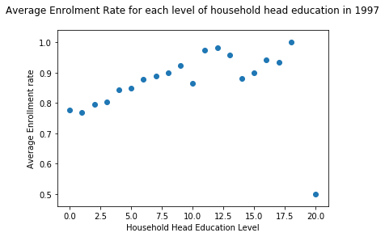

```python
# filtering records of year 97
progresa_97_df_1 = progresa_df[progresa_df.year==97]
# for each level of education, compute avg enrollment rate
ques_1_4_part1 = pd.DataFrame(progresa_97_df_1.groupby(['hohedu'])['sc97'].mean())
# reset index to access columns
ques_1_4_part1.reset_index(level=0, inplace = True)
plt.scatter(ques_1_4_part1.hohedu, ques_1_4_part1.sc97)
plt.xlabel('Household Head Education Level')
plt.ylabel('Average Enrollment rate')
plt.title('Average Enrolment Rate for each level of household head education in 1997\n')
plt.show()
```

We can see an approximate linear relationship. More the household head education level, more is the average enrollment rate. However, there is a significant drop at education level 20.

### 1.5 Graphical exploration, part 2

Create a histogram of village enrollment rates **among poor households in treated villages**, before and after treatment. Specifically, for each village, calculate the average rate of enrollment of poor households in treated villages in 1997, then compute the average rate of enrollment of poor households in treated villages in 1998. Create two separate histograms showing the distribution of these average enrollments rates, one histogram for 1997 and one histogram for

1. On each histogram, draw a vertical line that intersects the x-axis at the average value (across all households). Does there appear to be a difference? Is this difference statistically significant?

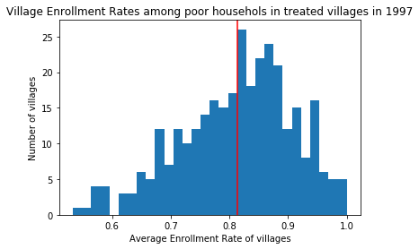

```python
# filter records for year 97, poor households and treatment group
progresa_treated_97_df = progresa_df[progresa_df.progresa=='basal'][progresa_df.poor == 'pobre'][progresa_df.year == 97]
# grouping by village, calculating average enrollment rates
x = progresa_treated_97_df.groupby(['village'])['sc'].mean()
plt.hist(x, bins = 30)
plt.axvline(x.mean(),color = 'Red')
plt.xlabel('Average Enrollment Rate of villages')
plt.ylabel('Number of villages')
plt.title('Village Enrollment Rates among poor househols in treated villages in 1997')
plt.show()
```

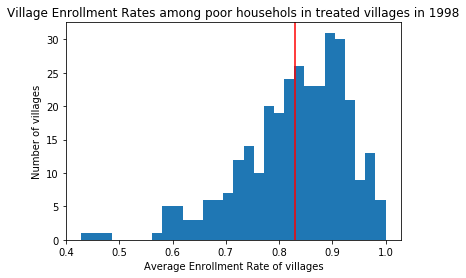

```python
# filter records for year 98, poor households and treatment group
progresa_treated_98_df = progresa_df[progresa_df.progresa=='basal'][progresa_df.poor == 'pobre'][progresa_df.year == 98]
# grouping by village, calculating average enrollment rates
x_1 = progresa_treated_98_df.groupby(['village'])['sc'].mean()
plt.hist(x_1, bins = 30)
plt.axvline(x_1.mean(), color='Red')
plt.xlabel('Average Enrollment Rate of villages')
plt.ylabel('Number of villages')
plt.title('Village Enrollment Rates among poor househols in treated villages in 1998')
plt.show()
```

```python
ttest_ind(x, x_1)
```

```
Ttest_indResult(statistic=-2.0157134865156379, pvalue=0.04424870036572115)
```

Histogram 1: The average rate of enrollments in 1997 is approximately equal to the average rate of enrollments for maximum number of villages. The average rate is slightly greater than 0.8.

Histogram 2: The average rate of enrollments in 1998 is less than average rate of enrollments for maximum number of villages. The average rate is higher than that of 1997.

Since the p-value of T-test is 0.04(less than 0.05), the difference is statistically significant

## Part 2: Measuring Impact

Our goal is to estimate the causal impact of the PROGRESA program on the social and economic outcomes of individuals in Mexico. We will focus on the impact of the program on the poor (those with poor=='pobre'), since only the poor were eligible to receive the PROGRESA assistance.

### 2.1 Cross-Sectional Estimator: T-test

Begin by estimating the impact of Progresa using "simple differences." Restricting yourself to data from 1998 (after treatment), calculate the average enrollment rate among **poor** households in the Treatment villages and the average enrollment rate among **poor** households in the control villages. Use a t-test to determine if this difference is statistically significant. What do you conclude?

```python
# treatment
print('Average enrollment rate among poor households in Treatment villages: ',progresa_treated_98_df.sc.mean())

#control
progresa_ctrl_98_df = progresa_df[progresa_df.progresa=='0'][progresa_df.poor == 'pobre'][progresa_df.year == 98]
print('Average enrollment rate among poor households in Control villages: ',progresa_ctrl_98_df.sc.mean())

print('Difference of means: ', progresa_treated_98_df.sc.mean() - progresa_ctrl_98_df.sc.mean())

print(ttest_ind(progresa_treated_98_df.sc.dropna(),progresa_ctrl_98_df.sc.dropna()))
```

```
Average enrollment rate among poor households in Treatment villages:  0.8464791213954308
Average enrollment rate among poor households in Control villages:  0.807636956730308
Difference of means:  0.0388421646651228
Ttest_indResult(statistic=8.3587205674183735, pvalue=6.636344447523235e-17)
```

Since p-value is less than 0.05, difference is statistically significant.

### 2.2 Cross-Sectional Estimator: Regression

Estimate the effects of Progresa on enrollment using a regression model, by regressing the 1998 enrollment rates **of the poor** on treatment assignment. Do not include any additional control variables. Discuss the following:

- Based on this model, how much did Progresa increase the likelihood of a child enrolling?
- How does your regression estimate compare to your t-test estimate from part 2.1?
- Based on this regression model, can we reject the null hypothesis that the treatment effects are zero?
- What is the counterfactual assumption underlying this regression?

Note: I recommend to use statsmodels.formula.api as this allows to use convenient R-style formulas and provedes nice summaries of the results.

```python
progresa_98_poor_df = progresa_df[progresa_df.poor == 'pobre'][progresa_df.year == 98]
model = smf.ols(formula = 'sc ~ progresa', data = progresa_98_poor_df)
print(model.fit().summary())
print('p-values:\n', model.fit().pvalues)
print('error:\n', model.fit().bse)
```

```
                            OLS Regression Results
==============================================================================
Dep. Variable:                     sc   R-squared:                       0.003
Model:                            OLS   Adj. R-squared:                  0.003
Method:                 Least Squares   F-statistic:                     69.87
Date:                Wed, 02 May 2018   Prob (F-statistic):           6.64e-17
Time:                        01:02:02   Log-Likelihood:                -11926.
No. Observations:               27450   AIC:                         2.386e+04
Df Residuals:                   27448   BIC:                         2.387e+04
Df Model:                           1
Covariance Type:            nonrobust
=====================================================================================
                        coef    std err          t      P>|t|      [0.025      0.975]
-------------------------------------------------------------------------------------
Intercept             0.8076      0.004    220.676      0.000       0.800       0.815
progresa[T.basal]     0.0388      0.005      8.359      0.000       0.030       0.048
==============================================================================
Omnibus:                     7638.939   Durbin-Watson:                   1.734
Prob(Omnibus):                  0.000   Jarque-Bera (JB):            15767.534
Skew:                          -1.767   Prob(JB):                         0.00
Kurtosis:                       4.140   Cond. No.                         3.01
==============================================================================

Warnings:
[1] Standard Errors assume that the covariance matrix of the errors is correctly specified.
p-values:
 Intercept            0.000000e+00
progresa[T.basal]    6.636344e-17
dtype: float64
error:
 Intercept            0.003660
progresa[T.basal]    0.004647
dtype: float64
```

1. Progressa increases the likelihood of a child enrolling by 0.0388.
2. The results of regression model and t-test are the same. People enrolled in treated villages more than the control villages by 0.0388.
3. We can reject the null hypothesis that the treatment effects are zero as p-value is very small.
4. The counterfactual assumption is that if the treatment was not provided, enrollment in treatment and control group would have been the same

### 2.3 Multiple Regression

Re-run the above regression estimated but this time include a set of relevant control variables. Include, for instance, age, distance to a secondary school, gender, education of household head, welfare index, indigenous, etc.

- How do the controls affect the point estimate of treatment effect?
- How do the controls affect the standard error on the treatment effect?
- How do you interpret the differences (or similarities) between your estimates of 2.2 and 2.3?

```python
model_mr = smf.ols(formula = 'sc ~ progresa + sc97 + grc97 + grc + age + dist_sec + sex + indig + fam_n + min_dist + dist_cap + hohwag + hohedu + welfare_index + hohage + hohsex', data = progresa_98_poor_df)
print(model_mr.fit().summary())
print('\npvalue: \n', model_mr.fit().pvalues)
print('\nError: \n', model_mr.fit().bse)
```

```
                            OLS Regression Results
==============================================================================
Dep. Variable:                     sc   R-squared:                       0.452
Model:                            OLS   Adj. R-squared:                  0.451
Method:                 Least Squares   F-statistic:                     1345.
Date:                Wed, 02 May 2018   Prob (F-statistic):               0.00
Time:                        01:02:02   Log-Likelihood:                -3347.5
No. Observations:               26155   AIC:                             6729.
Df Residuals:                   26138   BIC:                             6868.
Df Model:                          16
Covariance Type:            nonrobust
=====================================================================================
                        coef    std err          t      P>|t|      [0.025      0.975]
-------------------------------------------------------------------------------------
Intercept             0.7796      0.021     38.019      0.000       0.739       0.820
progresa[T.basal]     0.0319      0.004      9.048      0.000       0.025       0.039
sc97                  0.4969      0.006     82.295      0.000       0.485       0.509
grc97                -0.0258      0.002    -10.743      0.000      -0.030      -0.021
grc                   0.0373      0.002     15.904      0.000       0.033       0.042
age                  -0.0458      0.001    -35.134      0.000      -0.048      -0.043
dist_sec             -0.0052      0.001     -6.318      0.000      -0.007      -0.004
sex                   0.0154      0.003      4.512      0.000       0.009       0.022
indig                 0.0109      0.004      2.593      0.010       0.003       0.019
fam_n                 0.0007      0.001      0.846      0.397      -0.001       0.002
min_dist              0.0002   5.62e-05      3.878      0.000       0.000       0.000
dist_cap              0.0001   3.25e-05      3.534      0.000    5.12e-05       0.000
hohwag            -2.885e-06   2.47e-06     -1.168      0.243   -7.73e-06    1.96e-06
hohedu                0.0038      0.001      4.944      0.000       0.002       0.005
welfare_index     -1.074e-05   1.61e-05     -0.669      0.504   -4.22e-05    2.07e-05
hohage             -9.27e-05      0.000     -0.531      0.595      -0.000       0.000
hohsex                0.0134      0.007      1.968      0.049    5.11e-05       0.027
==============================================================================
Omnibus:                     6043.978   Durbin-Watson:                   1.772
Prob(Omnibus):                  0.000   Jarque-Bera (JB):            20975.619
Skew:                          -1.147   Prob(JB):                         0.00
Kurtosis:                       6.740   Cond. No.                     1.27e+04
==============================================================================

Warnings:
[1] Standard Errors assume that the covariance matrix of the errors is correctly specified.
```

[output cut: 27 more lines]

```
grc97                0.002400
grc                  0.002345
age                  0.001304
dist_sec             0.000818
sex                  0.003413
indig                0.004200
fam_n                0.000789
min_dist             0.000056
dist_cap             0.000033
hohwag               0.000002
hohedu               0.000763
welfare_index        0.000016
hohage               0.000175
hohsex               0.006829
dtype: float64
```

The likelihood of child enrolling has reduced to 0.0319. The p-value has also further reduced to 1.548814e-19. The error term has also reduced to 0.0035. Due to the impact of other variables in multiple regression, the estimate of progressa has lowered in 2.3

### 2.4 Difference-in-Difference, version 1 (tabular)

Thus far, we have computed the effects of Progresa by estimating the difference in 1998 enrollment rates across villages. An alternative approach would be to compute the treatment effect using a difference-in-differences framework.

Begin by estimating the average treatment effects of the program for poor households using data from 1997 and 1998. Specifically, calculate:

a) the difference (between 1997 and 1998) in enrollment rates among poor households in treated villages

b) the difference (between 1997 and 1998) in enrollment rates among poor households in control villages.

c) The difference between these two differences is your estimate.

- What is your estimate of the impact, and how does it compare to your earlier (simple difference) results?
- What is the counterfactual assumption underlying this estimate?

```python
# Treatment group
progresa_treatment_97 = progresa_df[progresa_df.poor == 'pobre'][progresa_df.year == 97][progresa_df.progresa == 'basal']
progresa_treatment_98 = progresa_df[progresa_df.poor == 'pobre'][progresa_df.year == 98][progresa_df.progresa == 'basal']
diff_treatment = progresa_treatment_97.sc.mean() - progresa_treatment_98.sc.mean()
print('Treatment', diff_treatment)

# Control Group
progresa_ctrl_97 = progresa_df[progresa_df.poor == 'pobre'][progresa_df.year == 97][progresa_df.progresa == '0']
progresa_ctrl_98 = progresa_df[progresa_df.poor == 'pobre'][progresa_df.year == 98][progresa_df.progresa == '0']
diff_control = progresa_ctrl_97.sc.mean() - progresa_ctrl_98.sc.mean()
print('Control', diff_control)

# Difference in Difference
print("Difference in Difference: ", diff_treatment - diff_control)
```

```
Treatment -0.023782233992046597
Control 0.007549046327276487
Difference in Difference:  -0.031331280319323085
```

The Difference in Difference is 0.0313 which is quite close to the estimate of multiple regression and slightly less than that of simple regression.

The counterfactual assumption is that if the treatment was not given, the difference in enrollment from 97 to 98 for treatment group would be the same as that of control group.

### 2.5 Difference-in-Difference, version 2 (regression)

Now use a regression specification to estimate the average treatment effects of the program in a difference-in-differences framework. Include at least 5 control variables.

- What is your estimate of the impact of Progresa? Be very specific in interpreting your coefficients and standard errors, and make sure to specify exactly what units you are measuring and estimating.
- How do these estimates of the treatment effect compare to the estimates based on the simple difference?
- How do these estimates compare to the difference-in-difference estimates from 2.4 above? What accounts for these differences?
- What is the counterfactual assumption underlying this regression?

```python
model_mr_did = smf.ols(formula='sc~progresa+year+progresa*year+age+dist_sec+sex+indig+min_dist+dist_cap+hohwag+hohedu + welfare_index + hohage + hohsex', data = progresa_df[progresa_df.poor == 'pobre'])
print(model_mr_did.fit().summary())
print('\npvalues: \n',model_mr_did.fit().pvalues)
print('\nError: \n',model_mr_did.fit().bse)
```

```
                            OLS Regression Results
==============================================================================
Dep. Variable:                     sc   R-squared:                       0.283
Model:                            OLS   Adj. R-squared:                  0.283
Method:                 Least Squares   F-statistic:                     1633.
Date:                Wed, 02 May 2018   Prob (F-statistic):               0.00
Time:                        01:02:03   Log-Likelihood:                -16472.
No. Observations:               57998   AIC:                         3.297e+04
Df Residuals:                   57983   BIC:                         3.311e+04
Df Model:                          14
Covariance Type:            nonrobust
==========================================================================================
                             coef    std err          t      P>|t|      [0.025      0.975]
------------------------------------------------------------------------------------------
Intercept                 -1.3029      0.424     -3.071      0.002      -2.134      -0.471
progresa[T.basal]         -2.9800      0.537     -5.545      0.000      -4.033      -1.927
year                       0.0280      0.004      6.428      0.000       0.019       0.037
progresa[T.basal]:year     0.0308      0.006      5.579      0.000       0.020       0.042
age                       -0.0658      0.000   -143.095      0.000      -0.067      -0.065
dist_sec                  -0.0096      0.001    -15.437      0.000      -0.011      -0.008
sex                        0.0332      0.003     12.425      0.000       0.028       0.038
indig                      0.0243      0.003      7.432      0.000       0.018       0.031
min_dist                   0.0004   4.39e-05      8.568      0.000       0.000       0.000
dist_cap                   0.0002   2.55e-05      7.235      0.000       0.000       0.000
hohwag                  1.008e-06   1.94e-06      0.519      0.603    -2.8e-06    4.81e-06
hohedu                     0.0072      0.001     12.117      0.000       0.006       0.008
welfare_index           2.002e-05   1.22e-05      1.640      0.101    -3.9e-06    4.39e-05
hohage                     0.0002      0.000      1.764      0.078   -2.62e-05       0.000
hohsex                     0.0014      0.005      0.270      0.787      -0.009       0.012
==============================================================================
Omnibus:                     5464.404   Durbin-Watson:                   1.492
Prob(Omnibus):                  0.000   Jarque-Bera (JB):             7176.348
Skew:                          -0.860   Prob(JB):                         0.00
Kurtosis:                       3.111   Cond. No.                     5.06e+05
==============================================================================

Warnings:
[1] Standard Errors assume that the covariance matrix of the errors is correctly specified.
[2] The condition number is large, 5.06e+05. This might indicate that there are
strong multicollinearity or other numerical problems.
```

[output cut: 21 more lines]

```
progresa[T.basal]         0.537377
year                      0.004352
progresa[T.basal]:year    0.005513
age                       0.000460
dist_sec                  0.000624
sex                       0.002672
indig                     0.003273
min_dist                  0.000044
dist_cap                  0.000026
hohwag                    0.000002
hohedu                    0.000594
welfare_index             0.000012
hohage                    0.000133
hohsex                    0.005206
dtype: float64
```

1. The impact of progresa according to this model is 0.0308. p-value is 2.43 * 10^-8 and standard error is 0.005
2. This is slightly less compared to simple differences.
3. This is slightly less than that of version1 in the previous part as this takes into account other control variables.
4. The counterfactual assumption is again that if the treatment was not given, the difference in enrollment from 97 to 98 for treatment group would be the same as that of control group

### 2.6 Summary

- Based on all the analysis you have undertaken to date, do you believe that Progresa had a causal impact on the enrollment rates of poor households in Mexico? Explain by referring to the methods and results above.

As per my analysis, Progresa had a causal impact on the enrollment rates of poor households in Mexico. Based on the methods used above, the enrolment rate improved by ~0.03 for the treatment groups. There was a slight change in the results due to control variables in Multiple Regression which was expected. Other than that, all the methods showed the same results.